# Optimal Temperature Kernels for Simulated Tempering

# Appendix

## Toy Multivariate Gaussian, All Dimensions

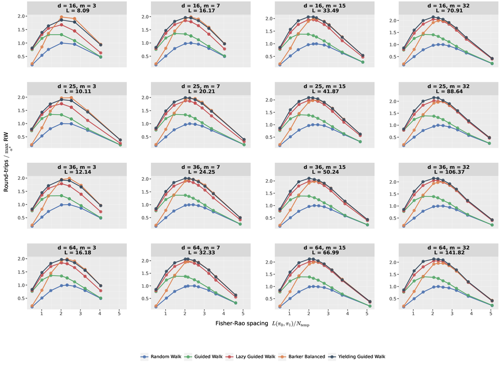

Scaled round-trips for the Toy Multivariate Gaussian target.

## Running Example: Bimodal Gaussian, All Diagnostics

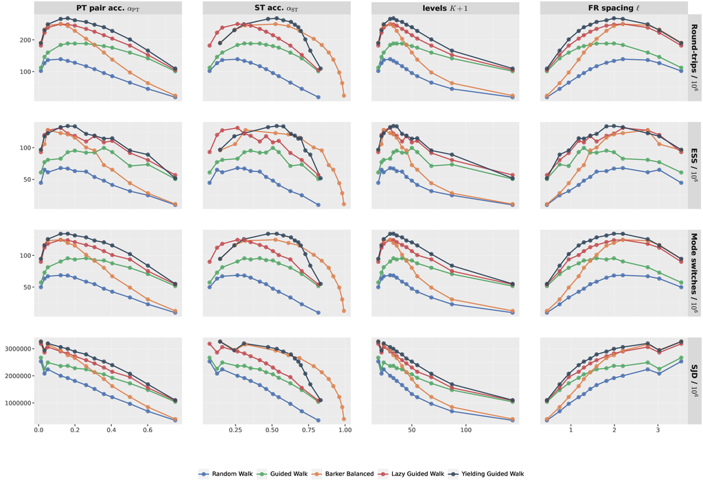

Round-trips, ESS, mode switches and SJD for the bimodal Gaussian target.

## Round-Trip Rate on the Lifted Graph

[figure not shown]

With $\textcolor{#1565c0}{a}=a_++a_-$ and $\textcolor{#2e7d32}{d}=a_+-a_-$, define $\lambda>0$ by $\displaystyle\cosh\lambda=\frac{\textcolor{#1565c0}{a}^2+2\textcolor{#1565c0}{a}\textcolor{#ef6c00}{\rho}+\textcolor{#2e7d32}{d}^2}{\textcolor{#1565c0}{a}^2-\textcolor{#2e7d32}{d}^2}$.

**Theorem** (Round-trip rate). For $a_+\ge a_-\ge0$ and $\textcolor{#ef6c00}{\rho}\in(0,1-\textcolor{#1565c0}{a}]$,
$$\mathrm{RTR}(a_+,a_-,\rho)
=\frac{\textcolor{#1565c0}{a}+\dfrac{\textcolor{#2e7d32}{d}^2}{\textcolor{#ef6c00}{\rho}}}
{2(N+1)\Bigl[N+\dfrac{\textcolor{#2e7d32}{d}^2}{\textcolor{#ef6c00}{\rho}\,\textcolor{#1565c0}{a}}\,\coth\Bigl(\dfrac{\lambda}{2}\Bigr)\tanh\Bigl(\dfrac{N\lambda}{2}\Bigr)\Bigr]} .$$

## Pointwise Reversible Off-Diagonal Mass Bound

**Lemma** (Pointwise reversible off-diagonal mass bound). Let $K$ be a Markov kernel on a discrete state space $\mathcal S$, **reversible** with respect to a probability distribution $\pi$. Fix $i\in\mathcal S$ and let $N(i)\subseteq\mathcal S\setminus\{i\}$ be any set of neighbouring states. Then
$$\textcolor{#1565c0}{\sum_{j\in N(i)} K(i,j)}
\;\le\;
\textcolor{#ef6c00}{\min\Bigl\{1,\;\sum_{j\in N(i)}\frac{\pi(j)}{\pi(i)}\Bigr\}} .$$

Moreover, the bound is **sharp** at state $i$: for any fixed values $\{\pi(j)/\pi(i):j\in N(i)\}$ there exist transition probabilities out of $i$, satisfying the pairwise reversible constraints, for which equality holds.

## Target Evaluations and Efficiency

[figure not shown]

Expected number of new target evaluations per ST update (solid lines, left axis) and relative efficiency (dotted lines, right axis) against the spacing $\ell$.

## Practical Ladder Calibration

|  | PT ladder calibration $\boldsymbol{a_{\mathrm{PT}}}$ | ST optimal regime $\boldsymbol{\ell}$ | ST optimal regime $\boldsymbol{\mathrm{Acc}}$ | ST optimal regime Relative efficiency | ST optimal regime Expected target evals. |
| --- | --- | --- | --- | --- | --- |
| Reversible methods |  |  |  |  |  |
| Random Walk | $0.092$ | $2.38$ | $0.234$ | $0.455$ | $1$ |
| Barker-Balanced | $0.090$ | $2.40$ | $0.459$ | $0.907$ | $3$ |
| Non-reversible methods |  |  |  |  |  |
| Guided Walk | $0.221$ | $1.73$ | $0.387$ | $0.648$ | $1$ |
| Lazy Guided Walk | $0.120$ | $2.20$ | $0.271$ | $0.952$ | $1.73$ |
| **Yielding Guided Walk** | $0.149$ | $2.04$ | $0.534$ | $\mathbf{1.000}$ | $2.17$ |

PT ladder calibration targets and the corresponding optimal ST regimes. The last column is the expected number of new target evaluations per ST temperature update, with the current target value cached.

›